# Machine Learning Kickstarter

Brant Faulkner & Courtney Allen

# 1 About the Project

The phenomenon of crowdfunding, an alternative financing approach, involves raising funds for a new business ventures via small amounts of capital from a large number of individuals. Crowdfunding is a relatively new phenomenon enabled by wide access to social media and internet-based financial technology services (Fintech)., It makes obtaining funding more accessible for entrepreneurs and small businesses, as compared to traditional banking and lending services.

Little academic research has been conducted on crowdfunding, and there are many interesting areas for investigation. From a financial perspective, it is disrupting the small- and medium- enterprise (SME) lending market. Economically, it may be changing the prevalence and makeup of SMEs. In terms of marketing, it gives consumers a greater say in the products they would like to see available, but also exposes them to increased risk. Regarding information and technology, it is enabling innovations on a public platform.

Our project would entail exploration of datasets regarding Indiegogo and Kickstarter projects., The primary project goal would be to construct a model that predicts crowdfunding success. In order to accomplish this, additional data sources may be required regarding consumer demand, small businesses, etc. From that predictive model, we seek to make recommendations (1) to entrepreneurs, regarding when and how to employ crowdfunding for project financing, and (2) to the lending services and venture capital industries, regarding how their business models should react.

From this independent study course, I expect to: * Use multiple publicly-available crowdfunding datasets and R programming, * Clean data and conduct primary research to obtain additional variables (as needed), * Apply statistical analysis techniques to describe trends, * Construct a model to predict crowdfunding success, and * Prescribe best practices for entrepreneurs to leverage crowdfunding.

# 2 Key Findings

# 3 Exploratory Analysis

## 3.1 $backers_count

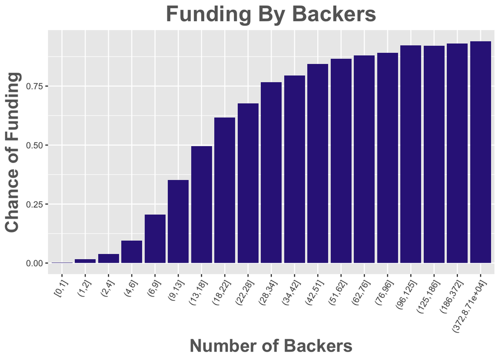

```r
df_backers = data.frame(funded = df_engr$funded, backers_count = df_engr$backers_count)
df_backers$df_bc_20 = cut(df_backers$backers_count, breaks = unique(quantile(df_backers$backers_count, seq(0, 1, by = .05))), include.lowest = TRUE)

df_backers %>%
  ggplot(aes(x = df_bc_20, y = funded)) +
  stat_summary(geom = "bar", fun.y = "mean", fill = "#332288") +
    labs(
    title = "Funding By Backers",
    x="Number of Backers",
    y="Chance of Funding") +
  theme_minimal() +
  theme_update(axis.text.x = element_text(angle = 60, hjust = 1)) +
  theme_update(plot.title = element_text(color="#666666", face="bold", size=22, hjust=0)) +
  theme_update(axis.title = element_text(color="#666666", face="bold", size=18)) +
  theme(plot.title = element_text(hjust = 0.5))
```

```r
#Clean Up
rm(df_backers)
```

## 3.2 Category variables

$category_parent_id, $category_slug - Some categories never fail in this dataset (only considered if n > 50): - design/product design (1098 projects) - film & video/documentary (2202 projects) - film & video/shorts (3513 projects) - games/tabletop games (1064 projects) - Most successful parent categories (only considered if n > 100): - 7 1,725 projects 81.2% successful - 11 12,087 projects 65.2% successful - 14 14,635 projects 59.2% successful - Least successful parent categories (only considered if n > 100): - 18 8,725 projects 39.7% successful - 16 1,638 projects 46.2% successful - 12 4,125 projects 46.9% successful

```r
# By main category
# 15 unique categories

df_engr %>%
  group_by(category) %>%
  summarise(count = n(),
            success_rate = round(mean(funded)*100, 2),
            mean(goal, na.rm = TRUE),
            min(percent_funded, na.rm = TRUE),
            median(percent_funded, na.rm = TRUE),
            max(percent_funded, na.rm = TRUE),
            mean(percent_funded, na.rm = TRUE),
            mean(backers_count),
            min(backers_count),
            median(backers_count),
            max(backers_count),
            mean(avg_contribution, na.rm = TRUE),
            min(avg_contribution, na.rm = TRUE),
            median(avg_contribution, na.rm = TRUE),
            max(avg_contribution, na.rm = TRUE)) %>%
  arrange(desc(count)) %>%
  ungroup(category)
```

```
## # A tibble: 14 x 16
##    category  count success_rate `mean(goal, na.rm =… `min(percent_funded,…
##    <fct>     <int>        <dbl>                <dbl>                 <dbl>
##  1 music     14635         59.2                7589.                    0
##  2 film&vid… 12087         65.2               22409.                    0
##  3 publishi…  8725         39.7                7951.                    0
##  4 art        6122         51.2                9139.                    0
##  5 games      4125         46.9               38009.                    0
##  6 design     1725         81.2               12981.                    0
##  7 technolo…  1638         46.2               68119.                    0
##  8 comics       72        100                 14186.                  100
##  9 crafts       61         96.7                3235.                    0
## 10 theater      57        100                  5994.                  100
## 11 food         45        100                 19737.                  100.
## 12 fashion      36        100                 18178.                  101.
## 13 dance        11        100                  3165.                  102.
## 14 photogra…    11        100                  9061.                  101.
## # ... with 11 more variables: `median(percent_funded, na.rm =
## #   TRUE)` <dbl>, `max(percent_funded, na.rm = TRUE)` <dbl>,
## #   `mean(percent_funded, na.rm = TRUE)` <dbl>,
## #   `mean(backers_count)` <dbl>, `min(backers_count)` <dbl>,
## #   `median(backers_count)` <dbl>, `max(backers_count)` <dbl>,
## #   `mean(avg_contribution, na.rm = TRUE)` <dbl>, `min(avg_contribution,
## #   na.rm = TRUE)` <dbl>, `median(avg_contribution, na.rm = TRUE)` <dbl>,
## #   `max(avg_contribution, na.rm = TRUE)` <dbl>
```

```r
#Logit
#Some categories significant
logit_category <- glm(funded ~ category, data = df_engr, family = binomial(link='logit'))
summary(logit_category)
```

```
##
## Call:
## glm(formula = funded ~ category, family = binomial(link = "logit"),
##     data = df_engr)
##
## Deviance Residuals:
##     Min       1Q   Median       3Q      Max
## -2.6145  -1.1975   0.9257   1.0244   1.3586
##
## Coefficients:
##                      Estimate Std. Error z value Pr(>|z|)
## (Intercept)           0.04705    0.02557   1.840 0.065732 .
## categorycomics       14.51902  104.03231   0.140 0.889006
## categorycrafts        3.33734    0.71945   4.639 3.51e-06 ***
## categorydance        14.51902  266.15714   0.055 0.956497
## categorydesign        1.41715    0.06674  21.235  < 2e-16 ***
## categoryfashion      14.51902  147.12390   0.099 0.921388
## categoryfilm&video    0.57870    0.03191  18.136  < 2e-16 ***
## categoryfood         14.51902  131.59162   0.110 0.912145
## categorygames        -0.17085    0.04034  -4.235 2.28e-05 ***
## categorymusic         0.32408    0.03060  10.590  < 2e-16 ***
## categoryphotography  14.51902  266.15714   0.055 0.956497
## categorypublishing   -0.46351    0.03365 -13.774  < 2e-16 ***
## categorytechnology   -0.19875    0.05577  -3.564 0.000365 ***
## categorytheater      14.51902  116.92222   0.124 0.901175
## ---
## Signif. codes:  0 '***' 0.001 '**' 0.01 '*' 0.05 '.' 0.1 ' ' 1
##
## (Dispersion parameter for binomial family taken to be 1)
##
##     Null deviance: 67757  on 49349  degrees of freedom
## Residual deviance: 65278  on 49336  degrees of freedom
## AIC: 65306
##
## Number of Fisher Scoring iterations: 13
```

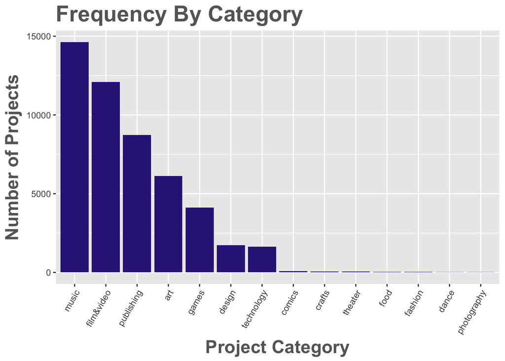

```r
df_engr %>%
  group_by(category) %>%
  summarise(count = n(),
            funded_rate = round(mean(funded)*100, 2)) %>%
  arrange(desc(count)) %>%
  ggplot(aes(x = reorder(category, -count), y = count)) +
  geom_bar(stat="identity", fill = "#332288") +
  labs(
    title = "Frequency By Category",
    x="Project Category",
    y="Number of Projects") +
  theme_minimal() +
  theme_update(axis.text.x = element_text(angle = 60, hjust = 1))
```

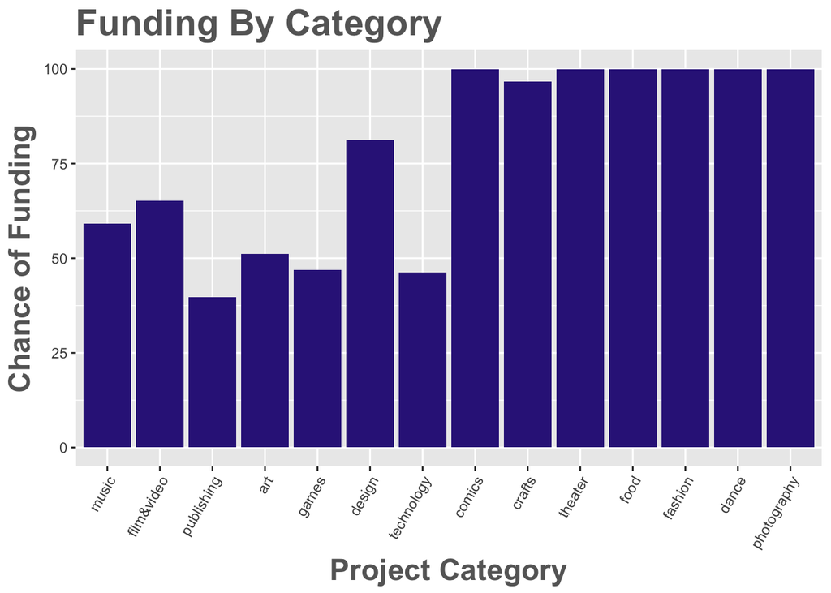

```r
df_engr %>%
  group_by(category) %>%
  summarise(count = n(),
            funded_rate = round(mean(funded)*100, 2)) %>%
  arrange(desc(count)) %>%
  ggplot(aes(x = reorder(category, -count), y = funded_rate)) +
  geom_bar(stat="identity", fill = "#332288") +
  labs(
    title = "Funding By Category",
    x="Project Category",
    y="Chance of Funding") +
  theme_minimal() +
  theme_update(axis.text.x = element_text(angle = 60, hjust = 1))
```

```r
# By subcategory
# 140 unique category/subcategory combinations
#df_cats %>%
#  group_by(as.character(category_slug)) %>%
#  summarise(n(),
#            success_rate = round(mean(funded)*100, 2),
#            min(percent_funded, na.rm = TRUE),
#            median(percent_funded, na.rm = TRUE),
#            max(percent_funded, na.rm = TRUE),
#            mean(percent_funded, na.rm = TRUE),
#            mean(backers_count),
#            min(backers_count),
#            median(backers_count),
#            max(backers_count),
#            mean(avg_contribution, na.rm = TRUE),
#            min(avg_contribution, na.rm = TRUE),
#            median(avg_contribution, na.rm = TRUE),
#            max(avg_contribution, na.rm = TRUE)) %>%
#  ungroup(category_slug)



#Clean up
rm(logit_category)
```

## 3.3 Explore $comments_count

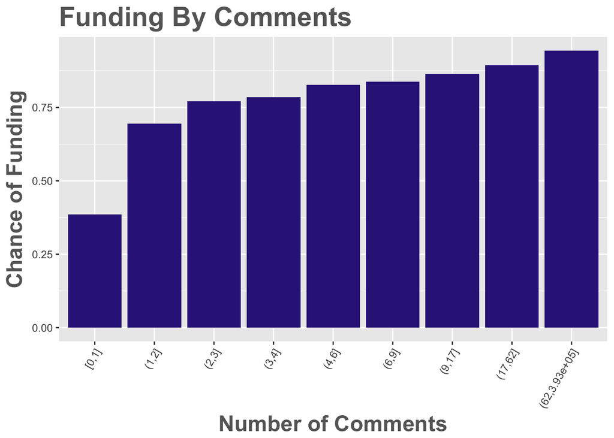

```r
df_commments = data.frame(funded = df_engr$funded,
                          comments_count = db_cleaned$comments_count)
df_commments$df_cc_20 = cut(df_commments$comments_count,
                            breaks = unique(quantile(df_commments$comments_count,
                                                     seq(0, 1, by = .05))),
                            include.lowest = TRUE)

df_commments %>%
  ggplot(aes(x = df_cc_20, y = funded)) +
  stat_summary(geom = "bar", fun.y = "mean", fill = "#332288") +
    labs(
    title = "Funding By Comments",
    x="Number of Comments",
    y="Chance of Funding") +
  theme_minimal() +
  theme_update(axis.text.x = element_text(angle = 60, hjust = 1))
```

```r
#Logit
#significant
logit_comments <- glm(funded ~ comments_count, data = df_commments, family = binomial(link='logit'))
summary(logit_comments)
```

```
##
## Call:
## glm(formula = funded ~ comments_count, family = binomial(link = "logit"),
##     data = df_commments)
##
## Deviance Residuals:
##     Min       1Q   Median       3Q      Max
## -8.4904  -1.1927   0.6619   1.1351   1.1622
##
## Coefficients:
##                Estimate Std. Error z value Pr(>|z|)
## (Intercept)    0.035838   0.009950   3.602 0.000316 ***
## comments_count 0.032261   0.001054  30.612  < 2e-16 ***
## ---
## Signif. codes:  0 '***' 0.001 '**' 0.01 '*' 0.05 '.' 0.1 ' ' 1
##
## (Dispersion parameter for binomial family taken to be 1)
##
##     Null deviance: 67757  on 49349  degrees of freedom
## Residual deviance: 64233  on 49348  degrees of freedom
## AIC: 64237
##
## Number of Fisher Scoring iterations: 12
```

```r
#Group into deciles and look as levels
#df_comments_count_filtered <- db_cleaned %>%
#  filter(comments_count <= 200) %>%
#  mutate(comment_count_10 = cut(comments_count, 10))

#df_comments_count_filtered %>%
#  ggplot() +
#  theme_minimal() +
#  ggtitle("$comment_count in Deciles") +
#  geom_histogram(aes(comment_count_10), stat = "count")

#df_comments_count_filtered %>%
#  group_by(comment_count_10) %>%
#  summarise(n(),
#            mean(comments_count),
#            success_rate = round(mean(funded)*100, 2),
#            mean(backers_count),
#            mean(avg_contribution, na.rm = TRUE)) %>%
#  ungroup(comment_count_10)

#Clean up
rm(logit_comments)
rm(df_commments)
```

## 3.4 $goal

Goal is likely a good predicter. The vast majority of goals are under $50,000. The likelihood of being funded decreases as goals get larger.

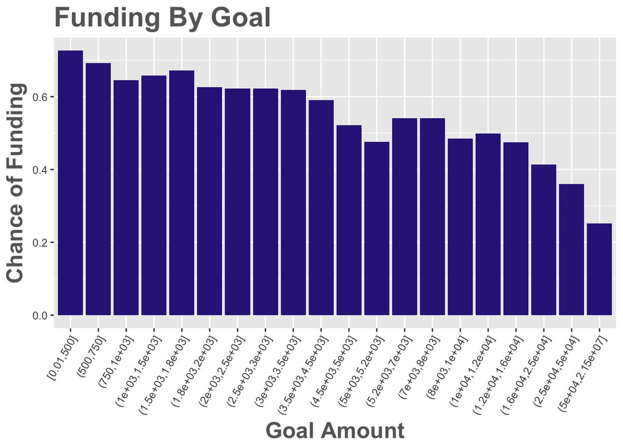

```r
df_engr %>%
  ggplot(aes(x = goal_20, y = funded)) +
  stat_summary(geom = "bar", fun.y = "mean", fill = "#332288") +
    labs(
    title = "Funding By Goal",
    x="Goal Amount",
    y="Chance of Funding") +
  theme_minimal() +
  theme_update(axis.text.x = element_text(angle = 60, hjust = 1))
```

```r
#Linear Models
summary(glm(funded ~ goal, data = df_engr))
```

```
##
## Call:
## glm(formula = funded ~ goal, data = df_engr)
##
## Deviance Residuals:
##     Min       1Q   Median       3Q      Max
## -0.5591  -0.5585   0.4410   0.4413   1.3494
##
## Coefficients:
##               Estimate Std. Error t value Pr(>|t|)
## (Intercept)  5.591e-01  2.240e-03 249.579   <2e-16 ***
## goal        -8.887e-08  1.011e-08  -8.791   <2e-16 ***
## ---
## Signif. codes:  0 '***' 0.001 '**' 0.01 '*' 0.05 '.' 0.1 ' ' 1
##
## (Dispersion parameter for gaussian family taken to be 0.2463031)
##
##     Null deviance: 12174  on 49349  degrees of freedom
## Residual deviance: 12155  on 49348  degrees of freedom
## AIC: 70904
##
## Number of Fisher Scoring iterations: 2
```

```r
summary(glm(funded ~ goal_20, data = df_engr))
```

```
##
## Call:
## glm(formula = funded ~ goal_20, data = df_engr)
##
## Deviance Residuals:
##     Min       1Q   Median       3Q      Max
## -0.7263  -0.5223   0.3081   0.4096   0.7480
##
## Coefficients:
##                           Estimate Std. Error t value Pr(>|t|)
## (Intercept)               0.726339   0.007955  91.309  < 2e-16 ***
## goal_20(500,750]         -0.034405   0.015033  -2.289   0.0221 *
## goal_20(750,1e+03]       -0.081382   0.011433  -7.118 1.11e-12 ***
## goal_20(1e+03,1.5e+03]   -0.068111   0.015761  -4.321 1.55e-05 ***
## goal_20(1.5e+03,1.8e+03] -0.053758   0.012555  -4.282 1.86e-05 ***
## goal_20(1.8e+03,2e+03]   -0.099882   0.012297  -8.123 4.67e-16 ***
## goal_20(2e+03,2.5e+03]   -0.103849   0.012195  -8.516  < 2e-16 ***
## goal_20(2.5e+03,3e+03]   -0.103880   0.011781  -8.818  < 2e-16 ***
## goal_20(3e+03,3.5e+03]   -0.108168   0.014221  -7.606 2.87e-14 ***
## goal_20(3.5e+03,4.5e+03] -0.135934   0.012492 -10.881  < 2e-16 ***
## goal_20(4.5e+03,5e+03]   -0.204050   0.010732 -19.013  < 2e-16 ***
## goal_20(5e+03,5.2e+03]   -0.250929   0.062445  -4.018 5.87e-05 ***
## goal_20(5.2e+03,7e+03]   -0.184895   0.011706 -15.795  < 2e-16 ***
## goal_20(7e+03,8e+03]     -0.185059   0.013565 -13.642  < 2e-16 ***
## goal_20(8e+03,1e+04]     -0.241528   0.011069 -21.821  < 2e-16 ***
## goal_20(1e+04,1.2e+04]   -0.226823   0.017024 -13.324  < 2e-16 ***
## goal_20(1.2e+04,1.6e+04] -0.251951   0.012943 -19.467  < 2e-16 ***
## goal_20(1.6e+04,2.5e+04] -0.312792   0.011810 -26.485  < 2e-16 ***
## goal_20(2.5e+04,5e+04]   -0.366339   0.012601 -29.072  < 2e-16 ***
## goal_20(5e+04,2.15e+07]  -0.474328   0.013739 -34.525  < 2e-16 ***
## ---
## Signif. codes:  0 '***' 0.001 '**' 0.01 '*' 0.05 '.' 0.1 ' ' 1
##
## (Dispersion parameter for gaussian family taken to be 0.2340022)
##
##     Null deviance: 12174  on 49349  degrees of freedom
## Residual deviance: 11543  on 49330  degrees of freedom
## AIC: 68394
##
## Number of Fisher Scoring iterations: 2
```

## 3.5 $launched_at

```r
df_engr %>%
  group_by(mo_yr_launched)  %>%
  summarise(n(),
            success_rate = round(mean(funded)*100, 2),
            mean(percent_funded, na.rm = TRUE),
            mean (avg_contribution, na.rm = TRUE)) %>%
  ungroup(mo_yr_launched)
```

```
## # A tibble: 57 x 5
##    mo_yr_launched `n()` success_rate `mean(percent_fun… `mean(avg_contrib…
##    <chr>          <int>        <dbl>              <dbl>              <dbl>
##  1 01-2010          118         58.5               82.4               68.3
##  2 01-2011          660         62.3               88.5               70.5
##  3 01-2012         1227         53.6              128.                67.1
##  4 01-2013         1388         55.6              124.                64.7
##  5 02-2010          139         62.6               89.9               75.1
##  6 02-2011          578         62.1               85.7               76.4
##  7 02-2012         1494         58.4              324.                71.9
##  8 02-2013         1435         59.0              121.                69.9
##  9 03-2010          209         65.1               89.6               78.5
## 10 03-2011          477         66.0              103.                76.7
## # ... with 47 more rows
```

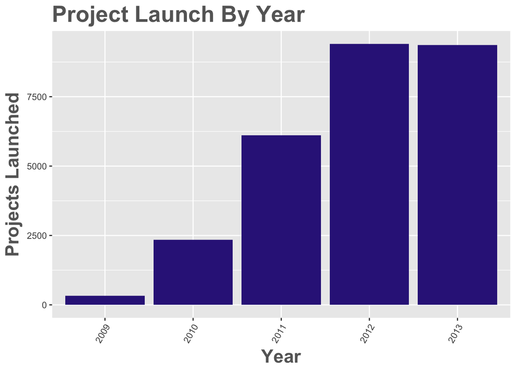

```r
df_engr %>%
  ggplot(aes(x = yr_launched, y = funded)) +
  geom_bar(stat="identity", fill = "#332288") +
    labs(
    title = "Project Launch By Year",
    x="Year",
    y="Projects Launched") +
  theme_minimal() +
  theme_update(axis.text.x = element_text(angle = 60, hjust = 1))
```

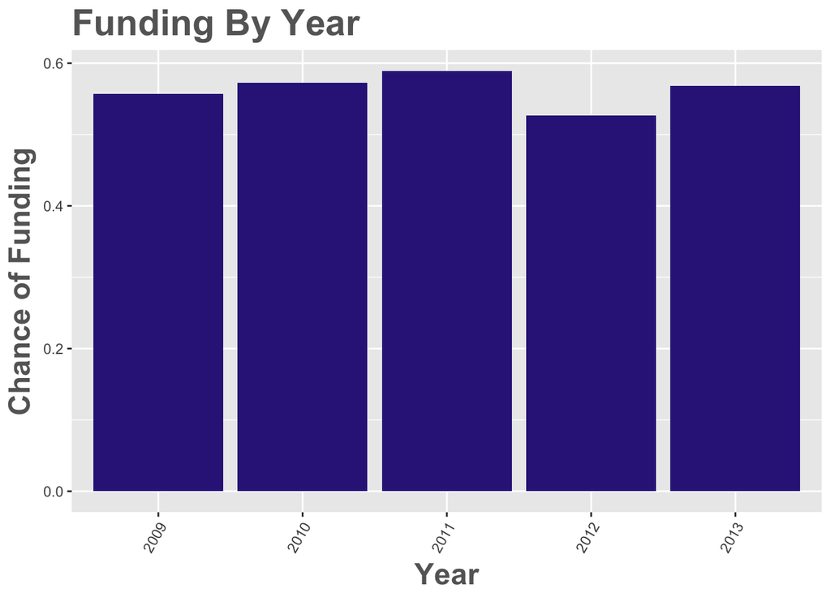

```r
df_engr %>%
  ggplot(aes(x = yr_launched, y = funded)) +
  stat_summary(geom = "bar", fun.y = "mean", fill = "#332288") +
    labs(
    title = "Funding By Year",
    x="Year",
    y="Chance of Funding") +
  theme_minimal() +
  theme_update(axis.text.x = element_text(angle = 60, hjust = 1))
```

[figure not shown]

```r
df_engr %>%
  ggplot(aes(x = mo_launched, y = funded)) +
  stat_summary(geom = "bar", fun.y = "mean", fill = "#332288") +
    labs(
    title = "Funding By Goal",
    x="Goal Amount",
    y="Chance of Funding") +
  theme_minimal() +
  theme_update(axis.text.x = element_text(angle = 60, hjust = 1))
```

```r
summary(glm(funded ~ mo_launched, data = df_engr))
```

```
##
## Call:
## glm(formula = funded ~ mo_launched, data = df_engr)
##
## Deviance Residuals:
##     Min       1Q   Median       3Q      Max
## -0.5938  -0.5554   0.4172   0.4446   0.4679
##
## Coefficients:
##                Estimate Std. Error t value Pr(>|t|)
## (Intercept)    0.562629   0.008523  66.012  < 2e-16 ***
## mo_launched02  0.031172   0.011843   2.632  0.00848 **
## mo_launched03  0.020148   0.011560   1.743  0.08137 .
## mo_launched04  0.005669   0.011639   0.487  0.62622
## mo_launched05 -0.023772   0.011199  -2.123  0.03378 *
## mo_launched06 -0.006424   0.011226  -0.572  0.56719
## mo_launched07 -0.011455   0.011280  -1.015  0.30989
## mo_launched08 -0.020658   0.011352  -1.820  0.06880 .
## mo_launched09 -0.007231   0.011434  -0.632  0.52716
## mo_launched10 -0.002315   0.011176  -0.207  0.83588
## mo_launched11 -0.012882   0.011260  -1.144  0.25261
## mo_launched12 -0.030529   0.012873  -2.371  0.01772 *
## ---
## Signif. codes:  0 '***' 0.001 '**' 0.01 '*' 0.05 '.' 0.1 ' ' 1
##
## (Dispersion parameter for gaussian family taken to be 0.2464786)
##
##     Null deviance: 12174  on 49349  degrees of freedom
## Residual deviance: 12161  on 49338  degrees of freedom
## AIC: 70950
##
## Number of Fisher Scoring iterations: 2
```

## 3.6 location variables

### 3.6.1 $country

The majority of projects are based in the United States. Domestic projects have a success rate about 7% higher than international projects.

```r
df_country <- data.frame(funded = df_engr$funded, country = db_cleaned$country, usa = df_engr$usa)

df_country %>%
  group_by(country) %>%
    summarise(count = n(), funded_rate = mean(funded)) %>%
  arrange(desc(count)) %>%
  ungroup(country)
```

```
## # A tibble: 5 x 3
##   country count funded_rate
##   <fct>   <int>       <dbl>
## 1 US      47007       0.561
## 2 GB       1986       0.492
## 3 CA        278       0.464
## 4 AU         54       0.556
## 5 NZ         25       0.52
```

```r
summary(lm(funded ~ usa, data = df_country))
```

```
##
## Call:
## lm(formula = funded ~ usa, data = df_country)
##
## Residuals:
##     Min      1Q  Median      3Q     Max
## -0.5610 -0.5610  0.4390  0.4390  0.5096
##
## Coefficients:
##             Estimate Std. Error t value Pr(>|t|)
## (Intercept)  0.49040    0.01026  47.814  < 2e-16 ***
## usa          0.07058    0.01051   6.717 1.88e-11 ***
## ---
## Signif. codes:  0 '***' 0.001 '**' 0.01 '*' 0.05 '.' 0.1 ' ' 1
##
## Residual standard error: 0.4965 on 49348 degrees of freedom
## Multiple R-squared:  0.0009133,  Adjusted R-squared:  0.0008931
## F-statistic: 45.11 on 1 and 49348 DF,  p-value: 1.88e-11
```

```r
#Clean up
rm(df_country)
```

## 3.7 $photo_key

There are not enough zero values for prediction, and a t-test shows no significant difference between having and not having a photo. This is probably not because photos don’t matter, but rather because the sample with no photo is too small to have statistical power.

```r
df_engr %>%
  group_by(photo_key) %>%
    summarise(n(), mean(funded)) %>%
  ungroup(photo_key)
```

```
## # A tibble: 2 x 3
##   photo_key `n()` `mean(funded)`
##       <dbl> <int>          <dbl>
## 1         0    25          0.68
## 2         1 49325          0.558
```

```r
t.test(funded ~ photo_key, data = df_engr)
```

```
##
##  Welch Two Sample t-test
##
## data:  funded by photo_key
## t = 1.2854, df = 24.026, p-value = 0.2109
## alternative hypothesis: true difference in means is not equal to 0
## 95 percent confidence interval:
##  -0.07413234  0.31899802
## sample estimates:
## mean in group 0 mean in group 1
##       0.6800000       0.5575672
```

## 3.8 $pledged

```r
# # Group into deciles and look as levels
# df_filtered_by_pledged <- db_cleaned %>%
#   filter(pledged < 200000) %>%
#   mutate(pledged_10 = cut(pledged, 10))
#
# #df_filtered_by_pledged %>%
#   group_by(pledged_10) %>%
#   summarise(n(),
#             mean(pledged),
#             mean(backers_count),
#             mean(avg_contribution, na.rm = TRUE)) %>%
#   ungroup(pledged_10)
#
# df_filtered_by_pledged %>%
#   ggplot() +
#   theme_minimal() +
#   ggtitle("$pledged in Deciles") +
#   geom_histogram(aes(pledged_10), stat = "count")
#
# #Clean up
# rm(df_filtered_by_pledged)
```

## 3.9 $spotlight

Spotlight is an ex post facto variable that features funded projects. [Kickstarter Spotlight](https://www.kickstarter.com/spotlight)

```r
df_engr %>%
  group_by(spotlight) %>%
    summarise(n(), mean(funded)) %>%
  ungroup(spotlight)
```

```
## # A tibble: 2 x 3
##   spotlight `n()` `mean(funded)`
##       <dbl> <int>          <dbl>
## 1         0 21831              0
## 2         1 27519              1
```

## 3.10 $staff_pick

This flag denotes projectsthat have received the “Projects We Love” badge and get prominantly features on the website, newsletters, and blogs. Kickstarter staff clearly has a great eye for promossing projects and/or some strong marketing impact. [Kickstarter - Projects We Love](https://www.kickstarter.com/discover/recommended)

```r
df_engr %>%
  group_by(staff_pick) %>%
    summarise(n(), mean(funded)) %>%
  ungroup(staff_pick)
```

```
## # A tibble: 2 x 3
##   staff_pick `n()` `mean(funded)`
##        <dbl> <int>          <dbl>
## 1          0 44081          0.524
## 2          1  5269          0.842
```

## 3.11 $funded

On average: projects that are funded far exceed their goal amount; the average contribution per backer is higher and there are more backers; and the goal amount tends to be significantly lower.

```r
df_engr %>%
  group_by(funded) %>%
  summarise(n(),
            mean(percent_funded, na.rm = TRUE),
            mean(avg_contribution, na.rm = TRUE),
            mean(goal, na.rm = TRUE),
            mean(backers_count),
            median(backers_count),
            max(backers_count),
            mean(avg_contribution, na.rm = TRUE)) %>%
  ungroup(funded)
```

```
## # A tibble: 2 x 8
##   funded `n()` `mean(percent_funde… `mean(avg_contribut… `mean(goal, na.r…
##    <dbl> <int>                <dbl>                <dbl>             <dbl>
## 1      0 21831                 10.6                 57.2            26047.
## 2      1 27519                577.                  82.9             8453.
## # ... with 3 more variables: `mean(backers_count)` <dbl>,
## #   `median(backers_count)` <int>, `max(backers_count)` <dbl>
```

## 3.12 $video_status

T test shows having a video to statistically significantly impact the success of the project.

```r
df_engr %>%
  group_by(video_status) %>%
    summarise(n(), mean(funded)) %>%
  ungroup(video_status)
```

```
## # A tibble: 2 x 3
##   video_status `n()` `mean(funded)`
##          <dbl> <int>          <dbl>
## 1            0  8882          0.408
## 2            1 40468          0.591
```

```r
t.test(funded ~ video_status, data = df_engr)
```

```
##
##  Welch Two Sample t-test
##
## data:  funded by video_status
## t = -31.728, df = 13074, p-value < 2.2e-16
## alternative hypothesis: true difference in means is not equal to 0
## 95 percent confidence interval:
##  -0.1940137 -0.1714361
## sample estimates:
## mean in group 0 mean in group 1
##        0.407791        0.590516
```

## 3.13 Social media connectedness variables

Social media shows an impact. Facebook seems to be the strongest and Youtube has a negative coefecient. Our hypothesis is that Facebook and Twitter may be used for promotion, while creators focusing on YouTube may over rely on their product content. Yet the most successfull creators have all three, which supports that YouTube is effective when paired with a comprehensive social media campaign.

```r
#facebook
df_engr %>%
  group_by(facebook) %>%
    summarise(n(), mean(funded)) %>%
  ungroup(facebook)
```

```
## # A tibble: 2 x 3
##   facebook `n()` `mean(funded)`
##      <dbl> <int>          <dbl>
## 1        0 36654          0.541
## 2        1 12696          0.605
```

```r
#twiter
df_engr %>%
  group_by(twitter) %>%
    summarise(n(), mean(funded)) %>%
  ungroup(twitter)
```

```
## # A tibble: 2 x 3
##   twitter `n()` `mean(funded)`
##     <dbl> <int>          <dbl>
## 1       0 46741          0.554
## 2       1  2609          0.617
```

```r
#youtube
df_engr %>%
  group_by(youtube) %>%
    summarise(n(), mean(funded)) %>%
  ungroup(youtube)
```

```
## # A tibble: 2 x 3
##   youtube `n()` `mean(funded)`
##     <dbl> <int>          <dbl>
## 1       0 45570          0.560
## 2       1  3780          0.528
```

```r
#social_media
df_engr %>%
  group_by(social_media) %>%
    summarise(n(), mean(funded)) %>%
  ungroup(social_media)
```

```
## # A tibble: 2 x 3
##   social_media `n()` `mean(funded)`
##          <dbl> <int>          <dbl>
## 1            0 48771          0.557
## 2            1   579          0.615
```

```r
lm_social_media <- lm(funded ~ social_media, data = df_engr)
summary(lm_social_media)
```

```
##
## Call:
## lm(formula = funded ~ social_media, data = df_engr)
##
## Residuals:
##     Min      1Q  Median      3Q     Max
## -0.6149 -0.5569  0.4430  0.4430  0.4430
##
## Coefficients:
##              Estimate Std. Error t value Pr(>|t|)
## (Intercept)  0.556950   0.002249 247.660  < 2e-16 ***
## social_media 0.057903   0.020762   2.789  0.00529 **
## ---
## Signif. codes:  0 '***' 0.001 '**' 0.01 '*' 0.05 '.' 0.1 ' ' 1
##
## Residual standard error: 0.4966 on 49348 degrees of freedom
## Multiple R-squared:  0.0001576,  Adjusted R-squared:  0.0001373
## F-statistic: 7.778 on 1 and 49348 DF,  p-value: 0.00529
```

```r
#social_media_count
df_engr %>%
  group_by(social_media_count) %>%
    summarise(n(), mean(funded)) %>%
  ungroup(social_media_count)
```

```
## # A tibble: 4 x 3
##   social_media_count `n()` `mean(funded)`
##                <dbl> <int>          <dbl>
## 1                  0 34484          0.543
## 2                  1 11226          0.594
## 3                  2  3061          0.581
## 4                  3   579          0.615
```

```r
lm_social_media_count <- lm(funded ~ social_media_count, data = df_engr)
summary(lm_social_media_count)
```

```
##
## Call:
## lm(formula = funded ~ social_media_count, data = df_engr)
##
## Residuals:
##     Min      1Q  Median      3Q     Max
## -0.6372 -0.5458  0.4237  0.4541  0.4541
##
## Coefficients:
##                    Estimate Std. Error t value Pr(>|t|)
## (Intercept)        0.545852   0.002592 210.568   <2e-16 ***
## social_media_count 0.030452   0.003400   8.956   <2e-16 ***
## ---
## Signif. codes:  0 '***' 0.001 '**' 0.01 '*' 0.05 '.' 0.1 ' ' 1
##
## Residual standard error: 0.4963 on 49348 degrees of freedom
## Multiple R-squared:  0.001623,   Adjusted R-squared:  0.001602
## F-statistic:  80.2 on 1 and 49348 DF,  p-value: < 2.2e-16
```

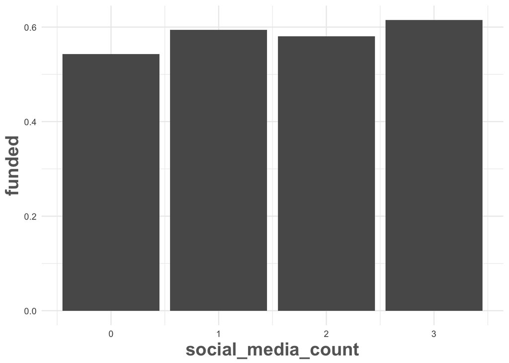

```r
df_engr %>%
  ggplot(aes(x = social_media_count, y = funded)) +
  stat_summary(geom = "bar", fun.y = "mean") +
  theme_minimal()
```

```r
#Clean up
rm(lm_social_media_count, lm_social_media)
```

## 3.14 $campaign_duration

Interestingly, campaign duration has an inverse relationship to the likelihood of receiving funding; longer campaign are associated with higher failure rates.

```r
#Linear Model
#not significant
lm_length <- glm(percent_funded ~ campaign_duration, data = df_engr)
summary(lm_length)
```

```
##
## Call:
## glm(formula = percent_funded ~ campaign_duration, data = df_engr)
##
## Deviance Residuals:
##     Min       1Q   Median       3Q      Max
##    -497     -330     -250     -197  4153152
##
## Coefficients:
##                   Estimate Std. Error t value Pr(>|t|)
## (Intercept)        506.246    273.642   1.850   0.0643 .
## campaign_duration   -5.074      7.139  -0.711   0.4773
## ---
## Signif. codes:  0 '***' 0.001 '**' 0.01 '*' 0.05 '.' 0.1 ' ' 1
##
## (Dispersion parameter for gaussian family taken to be 530257105)
##
##     Null deviance: 2.6167e+13  on 49349  degrees of freedom
## Residual deviance: 2.6167e+13  on 49348  degrees of freedom
## AIC: 1131439
##
## Number of Fisher Scoring iterations: 2
```

```r
#Logit
#significant
logit_length <- glm(funded ~ campaign_duration, data = df_engr, family=binomial(link='logit'))
summary(logit_length)
```

```
##
## Call:
## glm(formula = funded ~ campaign_duration, family = binomial(link = "logit"),
##     data = df_engr)
##
## Deviance Residuals:
##     Min       1Q   Median       3Q      Max
## -1.5155  -1.3146   0.9841   1.0450   1.4678
##
## Coefficients:
##                     Estimate Std. Error z value Pr(>|z|)
## (Intercept)        0.7946662  0.0243907   32.58   <2e-16 ***
## campaign_duration -0.0158282  0.0006355  -24.91   <2e-16 ***
## ---
## Signif. codes:  0 '***' 0.001 '**' 0.01 '*' 0.05 '.' 0.1 ' ' 1
##
## (Dispersion parameter for binomial family taken to be 1)
##
##     Null deviance: 67757  on 49349  degrees of freedom
## Residual deviance: 67121  on 49348  degrees of freedom
## AIC: 67125
##
## Number of Fisher Scoring iterations: 4
```

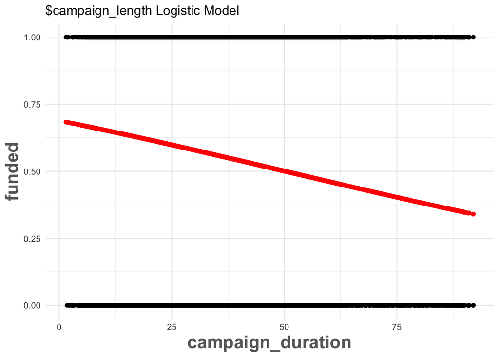

```r
df_engr %>%
  ggplot() +
  theme_minimal() +
  ggtitle("$campaign_length Logistic Model") +
  geom_point(aes(x=campaign_duration, y=funded), colour = "black") +
  geom_point(aes(x=campaign_duration, y=logit_length$fitted.values), colour = "red")
```

```r
rm(lm_length, logit_length)
```

## 3.15 $avg_contribution

Appears to have a skewed normal distribution with a mean of $72.

```r
#Chck for NA
anyNA(df_engr$avg_contribution)
```

```
## [1] TRUE
```

```r
mean(df_engr$avg_contribution, na.rm = TRUE)
```

```
## [1] 72.70791
```

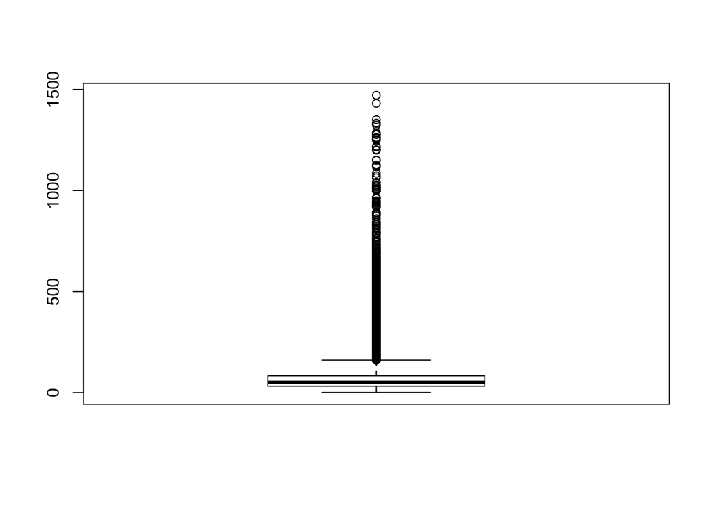

```r
# Apparently normal distribution
df_filtered_by_avg_contribution <- df_engr %>%
  filter(avg_contribution < 1500)

# Box Plot
boxplot(df_filtered_by_avg_contribution$avg_contribution)
```

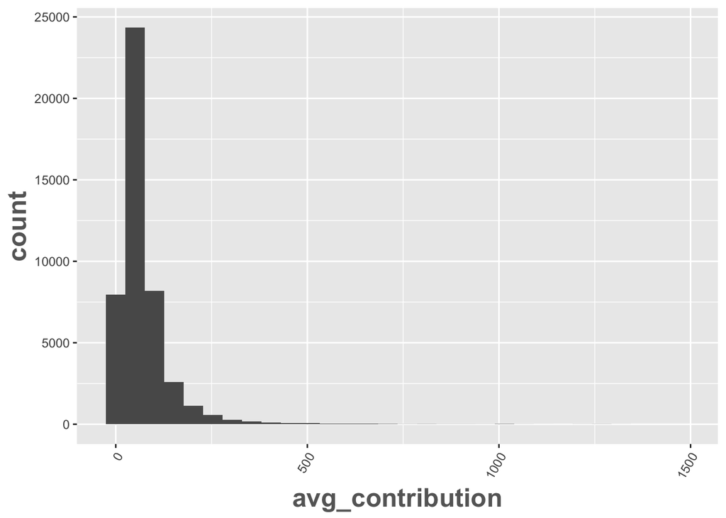

```r
# Histogram
df_filtered_by_avg_contribution %>%
  ggplot() +
  geom_histogram(aes(x = avg_contribution))
```

```r
#Clean up
rm(df_filtered_by_avg_contribution)
```

## 3.16 $percent_funded

Non-normal distribution shows that most projects over ~75% of their goal wind up being successful. There may be outside manipulation happening due to Kickstarter promotions of projects that are near their goals, or personal donations by the creators and/or creators personal connections.

```r
# Check for NA
anyNA(df_engr$percent_funded)
```

```
## [1] FALSE
```

```r
mean(df_engr$percent_funded, na.rm = TRUE)
```

```
## [1] 326.2655
```

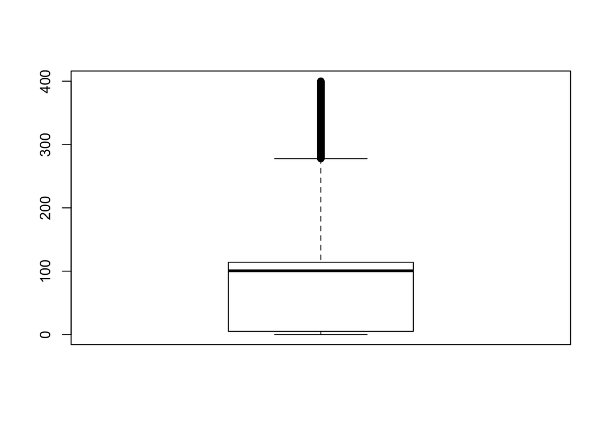

```r
df_filtered_by_percent_funded <- df_engr %>%
  filter(!is.na(percent_funded) & percent_funded <= 400)

# Box Plot
boxplot(df_filtered_by_percent_funded$percent_funded)
```

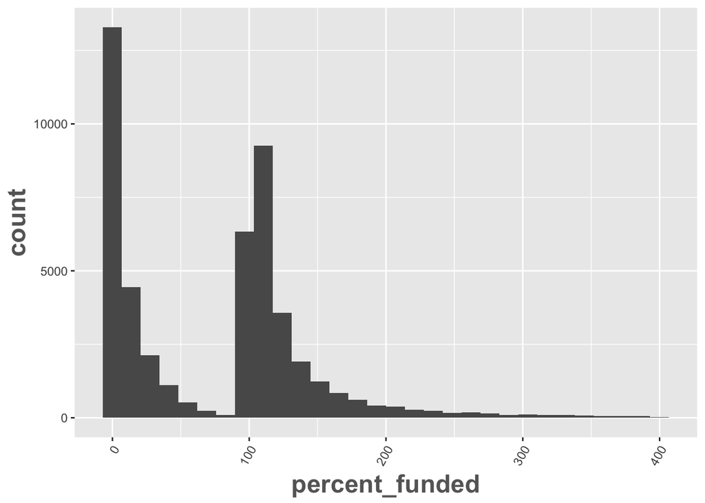

```r
# Non-normal distribution
df_filtered_by_percent_funded %>%
  ggplot() +
  geom_histogram(aes(x = percent_funded))
```

```r
#Clean up
rm(df_filtered_by_percent_funded)
```

## 3.17 $description_length

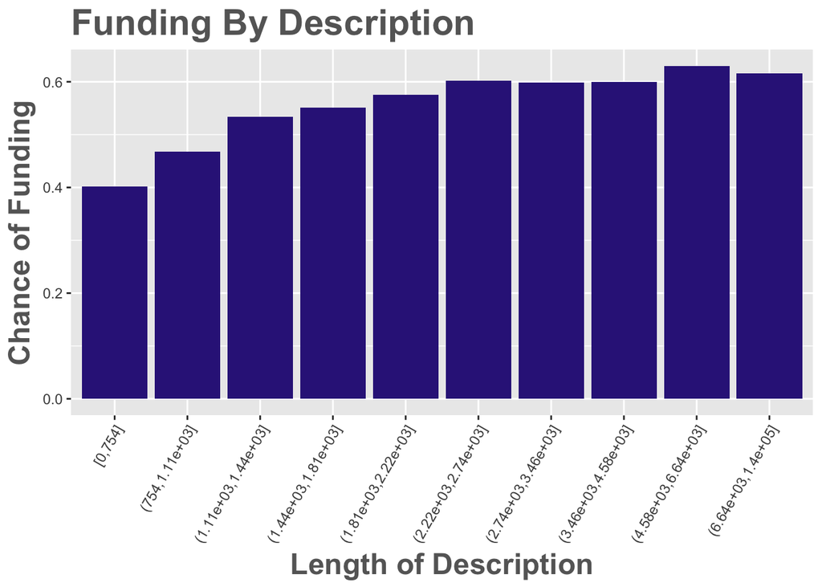

```r
df_engr %>%
  ggplot(aes(x = description_length_10, y = funded)) +
  stat_summary(geom = "bar", fun.y = "mean", fill = "#332288") +
    labs(
    title = "Funding By Description",
    x="Length of Description",
    y="Chance of Funding") +
  theme_minimal() +
  theme_update(axis.text.x = element_text(angle = 60, hjust = 1))
```

## 3.18 Profile variables

$profile_blurb, $profile_state

## 3.19 $rewards

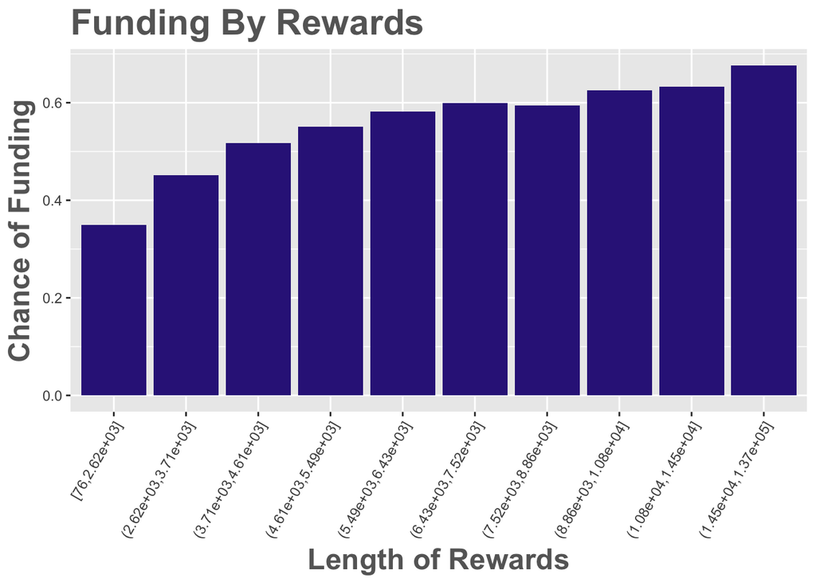

```r
df_engr %>%
  ggplot(aes(x = reward_length_10, y = funded)) +
  stat_summary(geom = "bar", fun.y = "mean", fill = "#332288") +
    labs(
    title = "Funding By Rewards",
    x="Length of Rewards",
    y="Chance of Funding") +
  theme_minimal() +
  theme_update(axis.text.x = element_text(angle = 60, hjust = 1))
```

## 3.20 $updates_count

## 3.21 Date variables

```r
#Average of 2-20 minutes difference btween deadline and failed_at, successful_at, state_changed_at
#Difference is not meaningful, so remove failed_at, successful_at, state_changed_at
ticktock <- data.frame(db_cleaned$created_at,
                       db_cleaned$deadline,
                       db_cleaned$failed_at,
                       db_cleaned$launched_at,
                       db_cleaned$state_changed_at,
                       db_cleaned$successful_at)

ticktock <- mutate(ticktock,
                   deadline_failed = db_cleaned.deadline - db_cleaned.failed_at,
                   deadline_success = db_cleaned.deadline - db_cleaned.successful_at,
                   deadline_state = db_cleaned.deadline - db_cleaned.state_changed_at)

mean(ticktock$deadline_failed, na.rm = TRUE)
```

```
## Time difference of -52.16174 secs
```

```r
mean(ticktock$deadline_success, na.rm = TRUE)
```

```
## Time difference of -112.5382 secs
```

```r
mean(ticktock$deadline_state)
```

```
## Time difference of -85.82944 secs
```

```r
rm(ticktock)
```

## 3.22 Not Fully Explored

More granular location variables would require more cleaning and may produce regional insights. * `location_name` * `location_state` * `location_type`

## 3.23 Rejected

We looked at this, yet did not find them to be predictive: * `project_id` * `disable_communicaiton`

```r
##$project_id
#A random identifier, cannot easily observe a pattern
range(db_cleaned$project_id)
```

```
## [1]      21109 2147466649
```